← jason2003wxy / notebook

# Business Driver Linear Regression Model

(Jason) Xiayan Wang

February 2021

# 1 Introduction

In this report, we model UK banking industry level **Loan & Advance volume** using economic and financial variables, provided by Bank of England. Given the developed model will be subject to expert override to reflect idiosyncratic characteristics of the bank, we choose to a model specification of linear regression with maximum three regressors.

# 2 Data Transformation

The nominal values of almost all economic variables are not stationary. For simplicity, we choose to model differences of the variables, in order to fit a linear regression model. Thus, we perform the following transformation on the time series data:

- log difference, $\Delta_t = \log(y_t) - \log(y_{t-1})$: is applied for nominal value or price, such as GDP values and equity indices
- absolute difference: $\Delta_t = y_t - ly_{t-1}$: is applied to the rates or ratios, such as interest rates
- as-is: $\Delta_t = y_t$: is applied to the growth rates such as household income growthes

# 3 Model Candidate Regressor Selection

To fit a linear regression model, we choose the transformed economic variables (i.e., regressors) that are stationary (model assumption) and statistically significant correlated to the response variable of the model. Specifically, an economic variable is chosen as a candidate of the regression model if all of the following conditions are met:

- its transformed time series must be stationary. The stationary tests are performed and described in Appendix A.
- the correlation between the response variable (differenced / transformed) and the economic variable or its lagged version (i.e., differences and lagged ldifferences by one quarter) must be statistically significant. The correlations are estimated with associated statistical significance tests and described in Appendix B.

To model Loan & Advance volume, a set of economic variables (together with their 1-quarter-lagged values) are selected according the above criteria and summarized in the following table.

```r
df_meta_info %>%
  filter(varR %in% nam_eco_sel$variable) %>%
  select(varR, desc, tranf_type) %>%
  DT::datatable(rownames = FALSE, options=list(pageLength = 5, searchHighlight = TRUE, scrollX = TRUE), caption="Chosen candidate regressor for linear model")
```

| varR | desc | tranf_type |
| --- | --- | --- |
| fx_USD_GBP | GBP-USD exchange rate index | diff_log |
| indx_BR_GDP_real | Brazil real GDP | diff_log |
| indx_EZ_GDP_real | Euro area real GDP | diff_log |
| indx_FR_GDP_real | France real GDP | diff_log |
| indx_UK_CPI | UK CPI | diff_log |
| indx_US_equity_SP | US equity prices | diff_log |
| indx_US_GDP_real | US real GDP | diff_log |
| indx_WLD_GDP_real | PPP-weighted World real GDP | diff_log |
| leve_Brent | Oil price | diff_log |
| leve_UK_corp_profit | UK corporate profits | diff_log |

[output cut: 9 more lines]

# 4 Model Development

Given the developed model will be subject to expert override to reflect idiosyncratic characteristics of the bank, a linear regression model with maximum three regressor is chosen. The following sections explain the strategy adopted to develop such a model. The model regressors contains all the selected economic variables and their 1-quarter-lagged values.

## 4.1 Mitigate multicollinearity

To mitigate multicollinearity in the model specification, we design the following strategy to remove regressors leading to strong multicollinearity:

- Step 1: Calculate condition number statistic for the regressor matrix
- Step 2: For each regressor, calculate condition number statistic of the regressor matrix without the interested regressor and then record the estimate deviation from the one obtained by Step 1.
- Step 3: Construct a new regressor matrix by remove the regressor associated with the largest deviation
- Repeat the above steps until the condition statistic of the re-constructed regressor matrix is below 30.

```r
tab_eco_modSel <- tibble::tibble(regressor = nam_2_modFit, varR = gsub("_lag1", "", nam_2_modFit), lagged = grepl("_lag1", nam_2_modFit)) %>%
  left_join(select(df_meta_info, varR, desc, tranf_type), by="varR")
tab_eco_modSel %>%
  select(-regressor) %>%
  DT::datatable(rownames = FALSE, options=list(pageLength = 5, searchHighlight = TRUE, scrollX = TRUE), caption="Chosen regressor for linear model fitting / selection")
```

| varR | lagged | desc | tranf_type |
| --- | --- | --- | --- |
| rate_EZ_policy | False | ECB policy rate | diff_abs |
| rate_HK_unemployment | False | Hong Kong unemployment rate | diff_abs |
| rate_UK_policy | False | Bank Rate | diff_abs |
| rate_UK_spread_corp_HY | False | Sterling HY corporate bond spread | diff_abs |
| rate_UK_spread_corp_IG | False | Sterling IG corporate bond spread | diff_abs |
| rate_US_spread_corp_HY | False | US dollar HY corporate bond spread | diff_abs |
| rate_US_spread_corp_IG | False | US dollar IG corporate bond spread | diff_abs |
| fx_USD_GBP | False | GBP-USD exchange rate index | diff_log |
| indx_BR_GDP_real | False | Brazil real GDP | diff_log |
| indx_EZ_GDP_real | False | Euro area real GDP | diff_log |

[output cut: 28 more lines]

## 4.2 Linear model selection

```r
eval(parse(text=paste0(
  "mod_fit_subset <- leaps::regsubsets(", nam_bus_driver, " ~ . , data=select(df_mod_fit, -date), nvmax=3)"
)))
## select and keep the drivers
nam_subset_modSelect <- intersect(names(coef(mod_fit_subset, which.max(summary(mod_fit_subset)$adjr2))), names(df_mod_fit))
tab_eco_modSel %>%
  filter(regressor %in% nam_subset_modSelect) %>%
  select(-regressor) %>%
  DT::datatable(options=list(dom = 't'), caption="Chosen three regressors by Best Subset algorithm")
```

|  | varR | lagged | desc | tranf_type |
| --- | --- | --- | --- | --- |
| 1 | indx_US_equity_SP | False | US equity prices | diff_log |
| 2 | indx_WLD_GDP_real | False | PPP-weighted World real GDP | diff_log |
| 3 | leve_UK_house_income | False | UK household income | diff_log |

## 4.3 Selected linear model

The linear 3-regressor-model with the highest overall fitness are summarized in the following table.

```r
eval(parse(text=paste0(
  "mod_lm_fit <- lm(", nam_bus_driver, " ~ . , data=select(df_mod_fit, one_of(nam_bus_driver, as.character(nam_subset_modSelect))))"
)))
mod_res_col <- tibble::lst(mod_lm_fit = mod_lm_fit)
mod_res_col$mod_est <- broom::tidy(mod_lm_fit)
mod_res_col$mod_est %>%
  mutate_at(c("estimate", "std.error", "statistic", "p.value"), function(x) round(x, digits=3)) %>%
  DT::datatable(options=list(dom = 't'), caption="Selected linear model", rownames = FALSE)
```

| term | estimate | std.error | statistic | p.value |
| --- | --- | --- | --- | --- |
| (Intercept) | -0.024 | 0.008 | -3.093 | 0.003 |
| indx_US_equity_SP | -0.25 | 0.05 | -5.042 | 0 |
| indx_WLD_GDP_real | 5.237 | 0.804 | 6.517 | 0 |
| leve_UK_house_income | -1.247 | 0.321 | -3.885 | 0 |

The overall fitness of the selected model, [adjusted $R^2$](https://en.wikipedia.org/wiki/Coefficient_of_determination), is 0.49. The standard residual diagnostic plots are shown below.

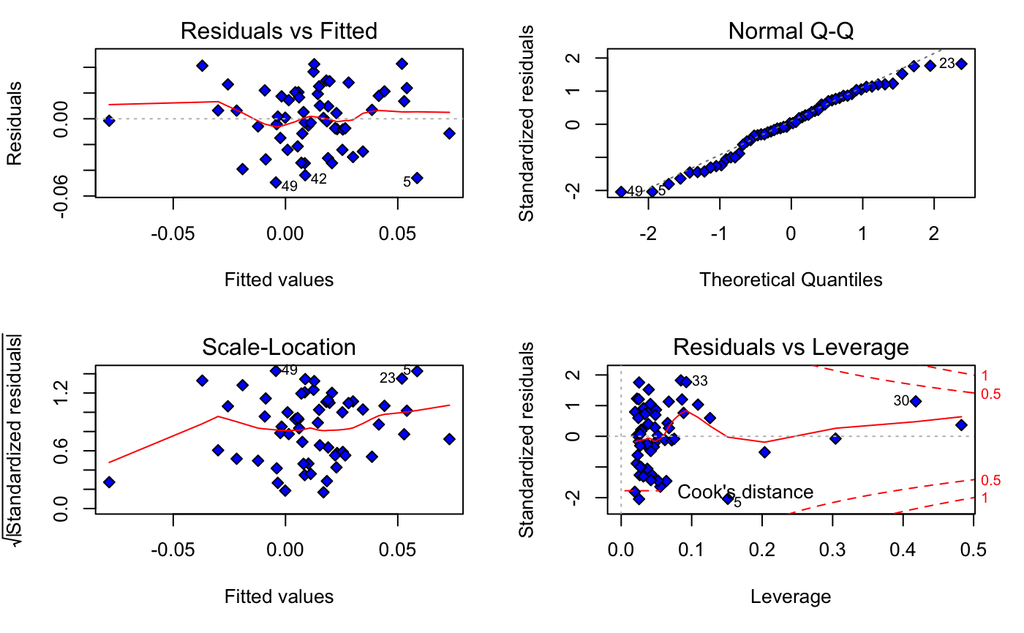

```r
par(mfrow=c(2,2))
plot(mod_res_col$mod_lm_fit, pch=23, bg='blue', cex=1)
par(mfrow=c(1,1))
```

# 5 Model Diagnositc

In this section, we firstly examine presence of multicolinearity. Next, we assess whether assumption of linear regression holds for the fitted model. There are four principal assumptions which justify the use of linear regression models for purposes of inference or prediction:

- linearity and additivity of the relationship between dependent and independent variables:
- statistical independence of the model residuals (in particular, no auto-correlation in the case of time series data)
- homoscedasticity (constant variance) of the model residual
- normality of the model residual distribution

```r
mod_res_col$mod_diag <- Test_Mod_Residuals(mod_res_col$mod_lm_fit)
```

## 5.1 Multicolinearity among model drivers

Firstly, we can conduct graphic inspection of correlation among the chosen regressors.

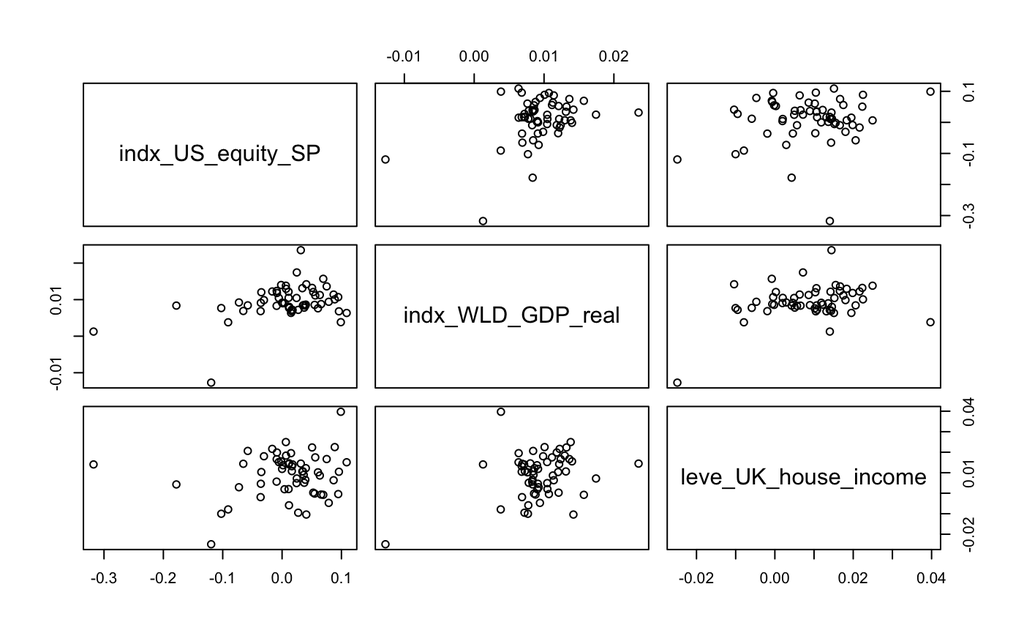

```r
nam_eco_modFit <- mod_res_col$mod_est$term[!grepl("Intercept", mod_res_col$mod_est$term)]
eval(parse(text = paste0(
  "pairs(~ ", paste(nam_eco_modFit, collapse = "+"), ", data=df_mod_fit)"
)))
```

To quantify multicolinearity, we can determine Variance Inflation Factor (VIF) of each model driver. The general rule of thumb is that VIFs exceeding 4 warrant further investigation, while VIFs exceeding 10 are signs of serious multicollinearity requiring correction. The following table summarizes VIF statistics for each regressor.

```r
data.frame(VIF = car::vif(mod_res_col$mod_lm_fit)) %>%
  DT::datatable(options=list(dom = 't'), caption="VIF of model drivers")
```

|  | VIF |
| --- | --- |
| indx_US_equity_SP | 1.17969246097016 |
| indx_WLD_GDP_real | 1.27378662597222 |
| leve_UK_house_income | 1.11686252254639 |

## 5.2 Residual linearity and additivity

Residual linearity can be assessed by graphic inspection.

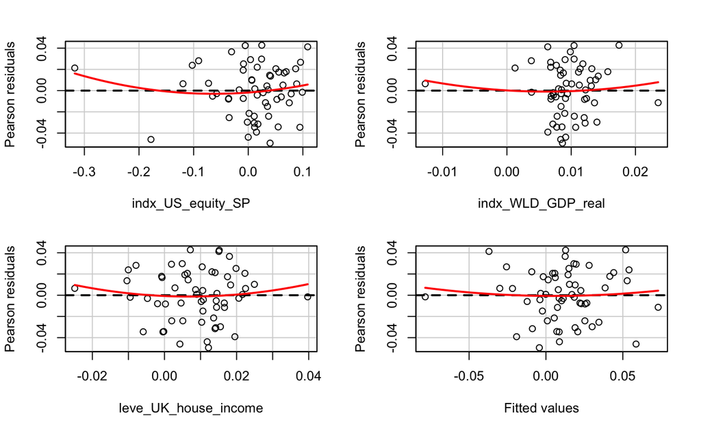

```
                     Test stat  Pr(>|t|)
indx_US_equity_SP    0.9772854 0.3328677
indx_WLD_GDP_real    0.5768605 0.5664759
leve_UK_house_income 0.7687573 0.4454497
Tukey test           0.4114982 0.6807072
```

The [Tukey](https://en.wikipedia.org/wiki/Tukey%27s_test_of_additivity) test of additivity result implies no statistically significant nonadditivity.

The following figure are the plots of the response variable against each numeric predictor, including a Lowess fit.

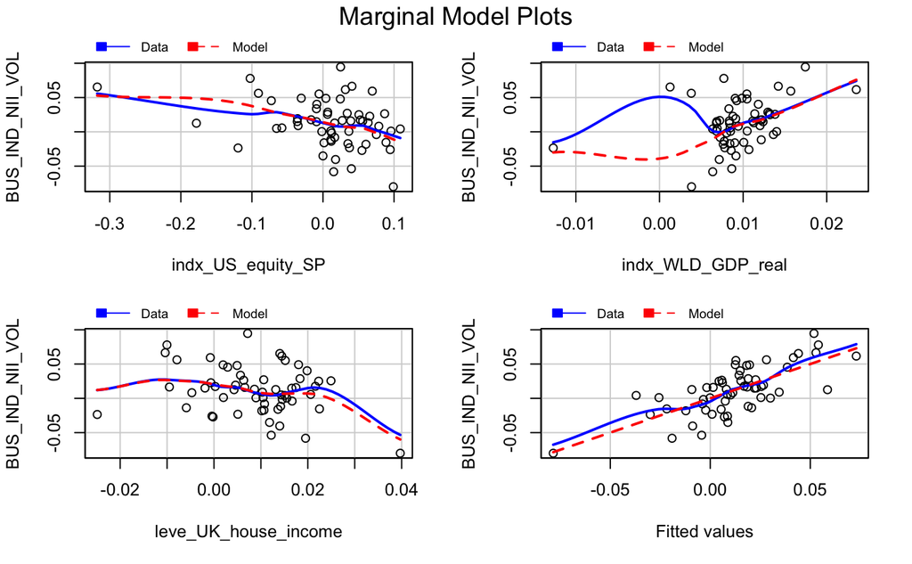

```r
car::marginalModelPlots(mod_res_col$mod_lm_fit)
```

## 5.3 Residual normality

To examine model residual normality, we perform both [Shapiro–Wilk](https://en.wikipedia.org/wiki/Shapiro%E2%80%93Wilk_test) and [Anderson–Darling](https://en.wikipedia.org/wiki/Anderson%E2%80%93Darling_test) tests. Both tests have null hypothesis of normality. The test results are summarized in the following table.

```r
tab_res <- mod_res_col$mod_diag %>%
  filter(grepl("normality", method))
DT::datatable(tab_res, rownames = FALSE, options=list(dom = 't'), caption="Residual normality tests")
```

| statistic | p.value | method | conclusion |
| --- | --- | --- | --- |
| 0.973703136426319 | 0.238772220781267 | Shapiro-Wilk normality test | Pass |
| 0.405215264878777 | 0.342118673354827 | Anderson-Darling normality test | Pass |

The test results indicates model residuals are normally distributed.

In addition, QQ plot is produced to inspect residual normality visually.

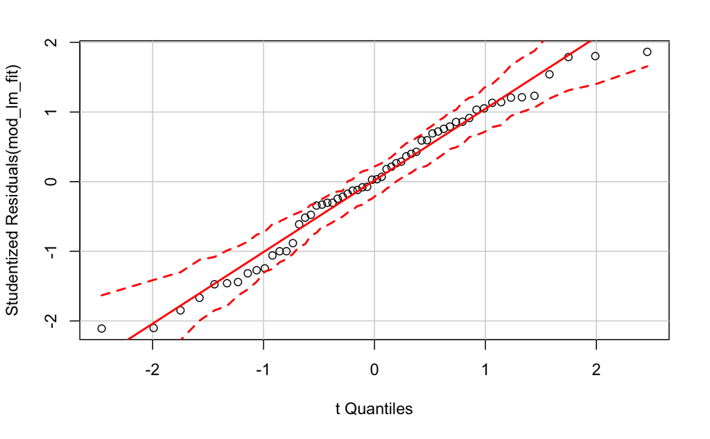

```r
car::qqPlot(mod_lm_fit)
```

## 5.4 Residual randomness and autocorrelation

[Durbin Waton](https://en.wikipedia.org/wiki/Durbin%E2%80%93Watson_statistic) test is perform to examine significance of residual auto-correlation. The test has null hypothesis of no 1-lag auto-correlation presence. The results are shown in the following table.

```r
mod_res_col$mod_diag %>%
  filter(grepl("Durbin", method)) %>%
  DT::datatable(rownames = FALSE, options=list(dom = 't'), caption="Residual autocorrelation test (1-lag)")
```

| statistic | p.value | method | conclusion |
| --- | --- | --- | --- |
| 1.66238945628064 | 0.0820379278914826 | Durbin-Watson test | Pass |

Both [Box-Ljung](https://en.wikipedia.org/wiki/Ljung%E2%80%93Box_test) and Box-Pierce tests are performed to examine significance of residual serial auto-correlation. Both tests have null hypothesis of no auto-correlation presence in the first ten lags. The results are shown in the following table.

```r
tab_res <- mod_res_col$mod_diag %>%
  filter(grepl("Box", method))
DT::datatable(tab_res, rownames = FALSE, options=list(dom = 't'), caption="Residual autocorrelation tests (10-lags)")
```

| statistic | p.value | method | conclusion |
| --- | --- | --- | --- |
| 22.5138575178065 | 0.0126904567013423 | Box-Pierce test | Fail zero-autocorrelation (10-lag) |
| 26.0740478175924 | 0.00364186184097981 | Box-Ljung test | Fail zero-autocorrelation (10-lag) |

## 5.5 Residual homoscedasticity

To examine homoscedasticity of the model residuals, [Breush Pagan](https://en.wikipedia.org/wiki/Breusch%E2%80%93Pagan_test) test is performed. The Breush Pagan test assesses whether the variance of the model residuals is dependent on the model regressors. If so, heteroskedasticity is present. The null hypothesis of the is that homoscedastic model residuals.

```r
tab_res <- mod_res_col$mod_diag %>%
  filter(grepl("Breusch", method))
DT::datatable(tab_res, rownames = FALSE, options=list(dom = 't'), caption="Residual homoscedasticity test")
```

| statistic | p.value | method | conclusion |
| --- | --- | --- | --- |
| 0.365863168704365 | 0.947200473507632 | studentized Breusch-Pagan test | Pass |

Since the p-value of the test indicates we can not reject the test null hypothesis, we can conclude that model residual homoscedasticity holds.

```r
save(nam_bus_driver, df_mod_fit, df_meta_info, mod_res_col, res_station, lst_data2Mod, file = paste0('DATA/mod_fit_', nam_bus_driver,'_PRA2016.Rdata'))
```

# 6 Appendix

## 6.1 Appendix A: stationarity tests

The stationary tests, namely, [augmented Dickey-Fuller](https://en.wikipedia.org/wiki/Dickey%E2%80%93Fuller_test) (ADF), [Kwiatkowski-Phillips-Schmidt-Shin](https://en.wikipedia.org/wiki/KPSS_test) (KPSS) and [Phillips-Perron](https://en.wikipedia.org/wiki/Phillips%E2%80%93Perron_test) (PP) are performed on each business driver and economic variable.

### 6.1.1 Appendix A.1: stationarity of business drivers

The following table summarizes the stationarity test results for the business drivers. We consider a variable that is able to pass any two of the three tests is stationary.

```r
res_station %>%
  filter(grepl("BUS_IND_", variable)) %>%
  DT::datatable(rownames = FALSE, options=list(dom = 't'), caption="Stationarity of business drivers")
```

| variable | res.ADF | res.PP | res.KPSS.level | Conclusion |
| --- | --- | --- | --- | --- |
| BUS_IND_NII_VOL | Non-stationary | Stationary | Non-stationary | Not |

### 6.1.2 Appendix A.2: stationarity of economic variables

The following table summarizes the stationarity test results for the economic variables. We consider a variable that is able to pass any two of the three tests is stationary.

```r
res_station %>%
  filter((!grepl("BUS_IND_", variable))) %>%
  DT::datatable(rownames = FALSE, options=list(pageLength = 5, searchHighlight = TRUE, scrollX = TRUE), caption="Stationarity of economic variables")
```

| variable | res.ADF | res.PP | res.KPSS.level | Conclusion |
| --- | --- | --- | --- | --- |
| rate_EZ_policy | Non-stationary | Stationary | Stationary | Stationary |
| rate_EZ_unemployment | Non-stationary | Non-stationary | Stationary | Not |
| rate_HK_unemployment | Stationary | Stationary | Stationary | Stationary |
| rate_UK_policy | Non-stationary | Stationary | Stationary | Stationary |
| rate_UK_spread_corp_HY | Stationary | Stationary | Stationary | Stationary |
| rate_UK_spread_corp_IG | Stationary | Stationary | Stationary | Stationary |
| rate_UK_unemployment | Non-stationary | Stationary | Non-stationary | Not |
| rate_US_policy | Non-stationary | Stationary | Stationary | Stationary |
| rate_US_spread_corp_HY | Stationary | Stationary | Stationary | Stationary |
| rate_US_spread_corp_IG | Stationary | Stationary | Stationary | Stationary |

[output cut: 38 more lines]

## 6.2 Appendix B: correlation analysis

### 6.2.1 Appendix B.1: correaltion to Loan & Advance volume

The following table summarizes correlation estimates between the Loan & Advance volume and each of the economic variables. In addition, the p-value of estimate significance is given for each correlation estimate. Furthermore, we estimate correlations between the Loan & Advance volume and lagged (1 quarter) economic variable. The results are summarized in the following table.

```r
res_corr_NII %>%
  DT::datatable(rownames = FALSE, options=list(pageLength = 5, searchHighlight = TRUE, scrollX = TRUE), caption="Correaltion between business driver and each of economic variables")
```

| variable | estimate | p.value | estimate.lag1 | p.value.lag1 | Conclusion |
| --- | --- | --- | --- | --- | --- |
| rate_EZ_policy | 0.275667073108571 | 0.0345777161449833 | 0.413613692613522 | 0.00124982639202529 | Significant |
| rate_EZ_unemployment | -0.24425607812776 | 0.0622694605202678 | -0.349644560472678 | 0.00713795287879703 | Significant |
| rate_HK_unemployment | -0.196138513123583 | 0.136530176334 | -0.288643647633067 | 0.0279922941297224 | Significant |
| rate_UK_policy | 0.140317563278032 | 0.289147338431097 | 0.384124332237031 | 0.00291235575279691 | Significant |
| rate_UK_spread_corp_HY | 0.293166019740816 | 0.0242318276189689 | -0.165079669108568 | 0.215583231819425 | Significant |
| rate_UK_spread_corp_IG | 0.267038533274294 | 0.0408976134081638 | -0.131436888708526 | 0.325372141223431 | Significant |
| rate_UK_unemployment | 0.0587204609478444 | 0.658654600588847 | -0.0204883420748829 | 0.878671253936963 | Not |
| rate_US_policy | 0.0384098485816912 | 0.772714763557434 | 0.185708951220997 | 0.162803696018579 | Not |
| rate_US_spread_corp_HY | 0.378521728882919 | 0.00311535790133758 | -0.0899872239517829 | 0.501731061935904 | Significant |
| rate_US_spread_corp_IG | 0.372504894055617 | 0.00366785920783127 | -0.0119303226812755 | 0.929174200360475 | Significant |

[output cut: 38 more lines]